# Project

Stanley

April 4, 2019

# Identifing Snakes Using Mitochondrial DNA

## Introduction

#### It can be hard to discover what types of snakes are found in a given area to test for biodiversity, and to identify unknown species. It is also hard to extract tissue or blood samples from snakes without harming them in order to do molecular analysis. Fortunately, there is a non-invasive method to get samples for molecular analysis by extracting mitochondrial DNA (mtDNA) from shedded snake skin. mtDNA is used instead of genomic DNA because only mtDNA is found in snake skin. Cytochrome c oxidase subunit I (COI) is a well conserved gene and is frequently used for barcoding to help identify species.

## Methods

#### I first aligned the mitochondrial genomes using the ClustalW method to make a phylogenetic tree in order to test for relatedness with the msa package. I then used the phangorn and ape packages to build the maximum likelihood trees with 100 bootstraps.

```
## CLUSTAL 2.1
##
## Call:
##    msa(snake.mt, "ClustalW")
##
## MsaDNAMultipleAlignment with 17 rows and 20390 columns
##      aln                                              names
##  [1] -----------------------...---------------------- Agkistrodon_pisci...
##  [2] -----------------------...---------------------- Ovophis_okinavensis
##  [3] -----------------------...---------------------- Dinodon_semicarin...
##  [4] -----------------------...---------------------- Pantherophis_slow...
##  [5] -----------------------...---------------------- Naja_naja
##  [6] -----------------------...---------------------- Enhydris_plumbea
##  [7] -----------------------...---------------------- Python_regius
##  [8] -----------------------...---------------------- Xenopeltis_unicolor
##  [9] -----------------------...---------------------- Cylindrophis_ruffus
## [10] -----------------------...---------------------- Boa_constrictor
## [11] -----------------------...---------------------- Acrochordus_granu...
## [12] -----------------------...---------------------- Ramphotyphlops_br...
## [13] -----------------------...---------------------- Rena_humilis
## [14] -----------------------...---------------------- schmidti_voucher
## [15] GCAATTTTTTATTTTTTTAAAAA...---------------------- Varanus_komodoensis
## [16] -----------------------...---------------------- Iguana_iguana
## [17] -----------------------...TATATATATATATATAAAATTT Plestiodon_egregius
##  Con -----------------------...---------------------- Consensus
```

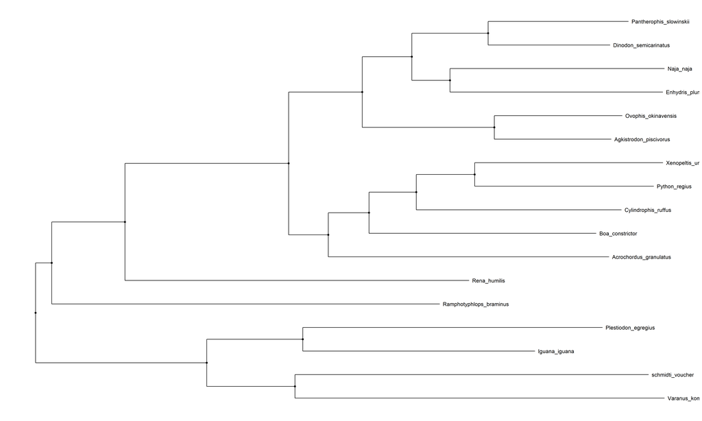

full mtDNA phylogenetic tree

```r
# an example with just one species.

agk = readDNAStringSet("./Project_Data/Agkistrodon_p_mt.fasta")
agkCOI = readDNAStringSet("./Project_Data/COI/COI_Agkistrodon_p.fasta")

agkaln = Biostrings::pairwiseAlignment(agkCOI, agk, type = "local")
```

#### From here I extracted the aligned part of the sequence and separated the views. Next I had to bind the extracted sequences.

```r
# an example with just one of the options

ext.agk = alignedPattern(agkaln)
view.agk = Views(agkaln, names = "agk")
print(ext.agk)
```

```
##   A DNAStringSet instance of length 1
##     width seq                                          names
## [1]  1546 GTGTATATCACCCGTTGACTA...TTTCATACCCAACAACACAT Agkistrodon pisci...
```

```r
print(view.agk)
```

```
##   Views on a 17213-letter DNAString subject
## subject: TTGTATGTAGCTTAAGCTTAAAGCATAGCACT...TTTTAATTACGTCCGAGATTTTTATATGTTG
## views:
##     start  end width
## [1]  6238 7783  1546 [GTGTATATCACCCGTTGACTATTTT...CCACTTTCATACCCAACAACACAT]
```

```r
# after getting the extracted COI sequence I bound them all together with c()
```

#### I then separated the ranges from the views.

```r
# an example from one of the species
agk.r = ranges(view.agk)
print(agk.r)
```

```
## IRanges object with 1 range and 0 metadata columns:
##           start       end     width
##       <integer> <integer> <integer>
##   agk      6238      7783      1546
```

```r
# I bound them all together with c()
```

## Results

#### From the extracted sequences, I aligned the COI sequences and then made another tree with the default settings and 100 bootstraps.

#### I also viewed all the ranges and compared them so you can see that the ranges are different.

```
## IRanges object with 16 ranges and 0 metadata columns:
##                                    start       end     width
##                                <integer> <integer> <integer>
##         Agkistrodon_piscivorus      6238      7783      1546
##   Amphisbaena_schmidit_voucher      5510      7045      1536
##         Acrochordus_granulatus      6405      7950      1546
##                Boa_constrictor      6992      8537      1546
##            Cylindrophis_ruffus      6357      7919      1563
##          Dinodon_semicarinatus      6220      7765      1546
##               Enhydris_plumbea      6319      7920      1602
##                  Iguana_iguana      5327      6874      1548
##                      Naja_naja      6221      7822      1602
##            Ovophis_okinavensis      6411      7956      1546
##        Pantherophis_slowinskii      6216      7761      1546
##            Plestiodon_egregius      5288      6835      1548
##                  Python_regius      6174      7775      1602
##        Ramphotyphlops_braminus      5105      6664      1560
##                   Rena_humilis      5196      6743      1548
##            Xenopeltis_unicolor      7120      8665      1546
```

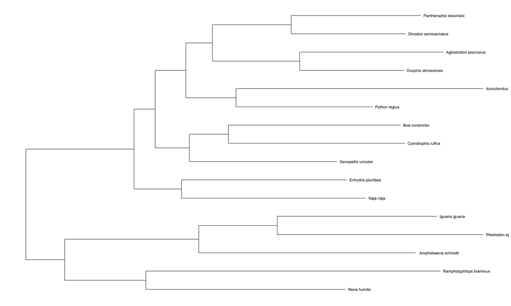

COI sequence

## Conclusion

#### By doing a local alignment with just the COI genes with a reference mtDNA sequence from NCBI and by extracting the ranges, you should be able to identify an unknown snake or lizard from mtDNA extracted from their shedded skin.

# References

https://cran.r-project.org/web/packages/phangorn/vignettes/Trees.pdf phangorn help